# US Arrests Data Transformations

Katie, Sarah, Meerim

February 29, 2016

source(‘~/Documents/Hertie 2016/Collaborative Social Science Data/Assignment1repo/USArrests_SourceFile.R’)

## Violent Crime Rates by US State

This data set contains statistics, in arrests per 100,000 residents for assault, murder, and rape in each of the 50 US states in 1973. Also given is the percent of the population living in urban areas.

```
##      Murder          Assault         UrbanPop          Rape
##  Min.   : 0.800   Min.   : 45.0   Min.   :32.00   Min.   : 7.30
##  1st Qu.: 4.075   1st Qu.:109.0   1st Qu.:54.50   1st Qu.:15.07
##  Median : 7.250   Median :159.0   Median :66.00   Median :20.10
##  Mean   : 7.788   Mean   :170.8   Mean   :65.54   Mean   :21.23
##  3rd Qu.:11.250   3rd Qu.:249.0   3rd Qu.:77.75   3rd Qu.:26.18
##  Max.   :17.400   Max.   :337.0   Max.   :91.00   Max.   :46.00
```

The data examined and transformed is a data frame with 50 observations on 4 variables:

```
## [1] "Murder"   "Assault"  "UrbanPop" "Rape"
```

## Frequency of Violent Crime Arrests by Crime Type

*Arrests for the US states in 1973 Per 100,000 Residents*

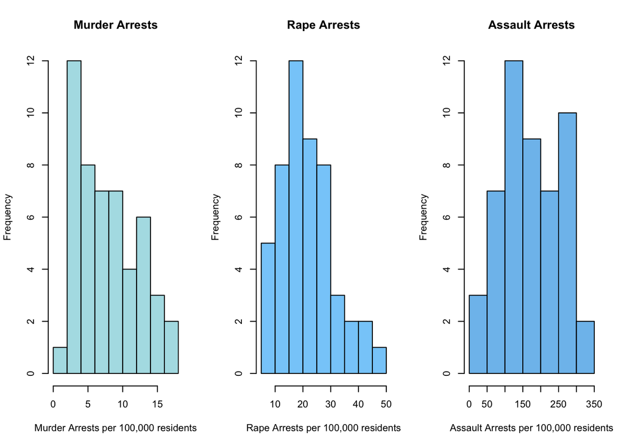

## Overview of Violent Crime Arrests

All three variables vary widely, but **assault** has an especially wide distribution. There are far more assaults arrests per 100,000 than the other types of violent crime.

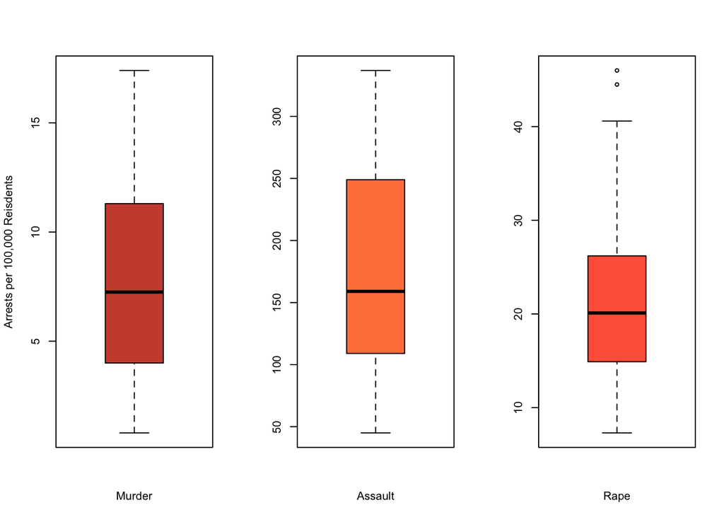

## Violent Arrests and Urban Populations

Violent arrests plotted against the percent of the urban population. Murder, assault and rape are all positively correlated with the percentage of urban population. The murder does not appear to have a strong effect, though the best-fit line shows a slightly positve correlation.

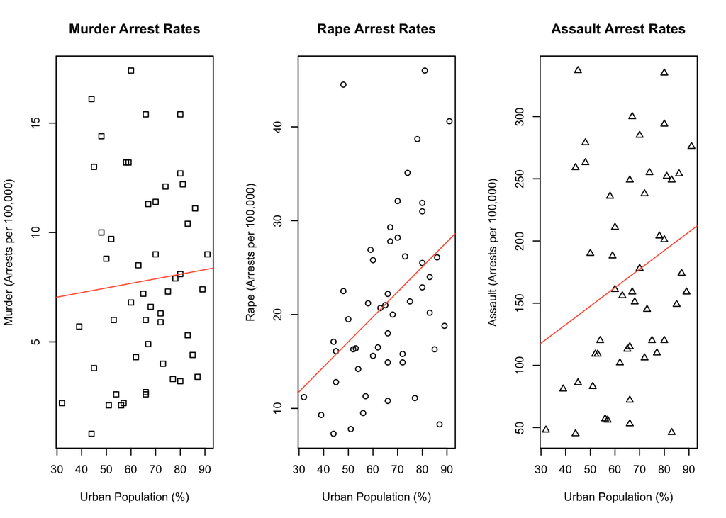

## Correlations between Urban Population and Violent Crime Rate

The correlation between the percentage of urban population and assault is **0.26**, indicating a positive correlation.

```
##
##  Pearson's product-moment correlation
##
## data:  log(USArrests$UrbanPop) and USArrests$Assault
## t = 1.8481, df = 48, p-value = 0.07075
## alternative hypothesis: true correlation is not equal to 0
## 95 percent confidence interval:
##  -0.02219982  0.50020295
## sample estimates:
##       cor
## 0.2577405
```

The correlation between the percentage of urban population and rape is **0.41**, indicating a strong, positive correlation.

```
##
##  Pearson's product-moment correlation
##
## data:  log(USArrests$UrbanPop) and USArrests$Rape
## t = 3.1496, df = 48, p-value = 0.002812
## alternative hypothesis: true correlation is not equal to 0
## 95 percent confidence interval:
##  0.1531423 0.6206962
## sample estimates:
##       cor
## 0.4138489
```

The correlation between the percentage of urban population and murder is **0.08**, indicating a weakly positive correlation.

```
##
##  Pearson's product-moment correlation
##
## data:  log(USArrests$UrbanPop) and USArrests$Murder
## t = 0.58188, df = 48, p-value = 0.5634
## alternative hypothesis: true correlation is not equal to 0
## 95 percent confidence interval:
##  -0.1992980  0.3537983
## sample estimates:
##        cor
## 0.08369253
```